# Gráficas, ejes y figuras

## Subgráficas

Se utiliza la **función subplots()**.

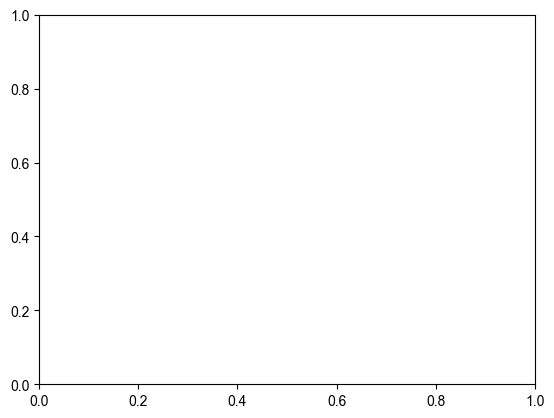

```python
# Sin argumentos
import matplotlib.pyplot as plt
import seaborn as sns
fig = plt.subplot()
sns.set_style('darkgrid')
```

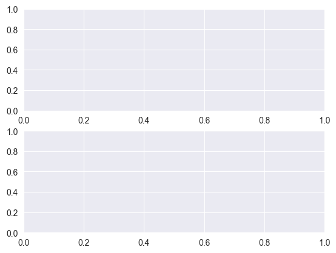

```python
figs,axs = plt.subplots(2)
```

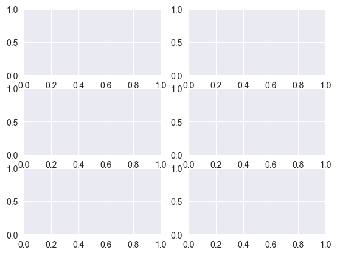

```python
figs, axs = plt.subplots(3,2)
```

Cada columna comparte el eje **x** (**sharex**=col) y todas las subgráficas comparten el eje **y** (**sharey**=all)

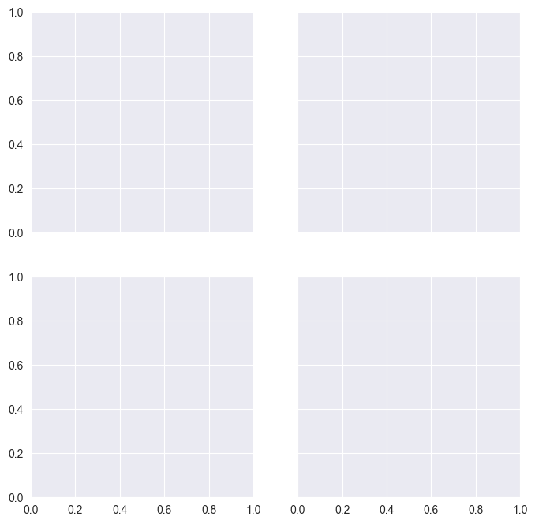

```python
fig,axs = plt.subplots(2,2,figsize=(8,8),sharex='col',sharey='all')
```

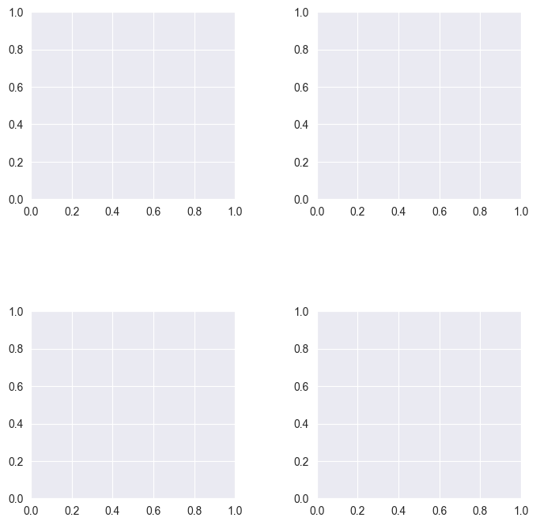

```python
fig,axs = plt.subplots(2,2,figsize=(8,8))
plt.subplots_adjust(wspace=0.4,hspace=0.6)
```

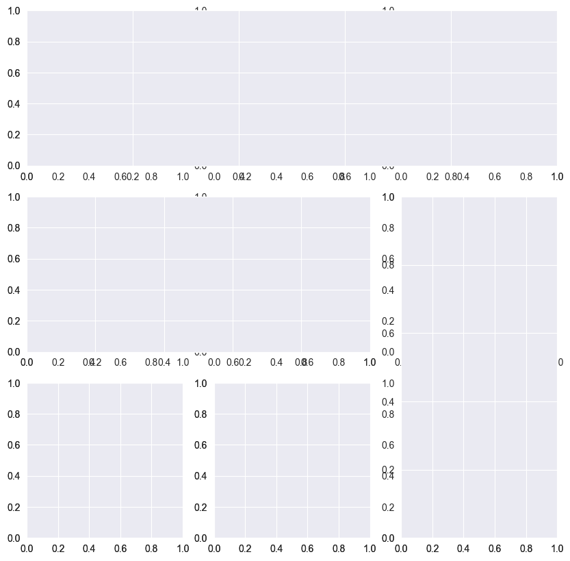

```python
fig, axs = plt.subplots(3,3,figsize=(10,10))
ax1 = plt.subplot2grid((3,3),(0,0),colspan=3)
ax2 = plt.subplot2grid((3,3),(1,0),colspan=2)
ax3 = plt.subplot2grid((3,3),(1,2),rowspan=2)
ax4 = plt.subplot2grid((3,3),(2,0))
ax5 = plt.subplot2grid((3,3),(2,1))
```

```python
import pandas as pd
internet_users = pd.read_csv('InternetUsers.csv')
internet_users
```

|  | Country Name | Country Code | 1990 | 1991 | 1992 | 1993 | 1994 | 1995 | 1996 | 1997 | ... | 2010 | 2011 | 2012 | 2013 | 2014 | 2015 | 2016 | 2017 | 2018 | 2019 |
| --- | --- | --- | --- | --- | --- | --- | --- | --- | --- | --- | --- | --- | --- | --- | --- | --- | --- | --- | --- | --- | --- |
| 0 | Aruba | ABW | 0.0 | 0.000000 | 0.000000 | 0.000000 | 0.000000 | 0.000000 | 2.768383 | NaN | ... | 62.00 | 69.000 | 74.000000 | 78.9 | 83.78000 | 88.661227 | 93.542454 | 97.170000 | NaN | NaN |
| 1 | Afghanistan | AFG | 0.0 | 0.000000 | 0.000000 | 0.000000 | 0.000000 | 0.000000 | NaN | NaN | ... | 4.00 | 5.000 | 5.454545 | 5.9 | 7.00000 | 8.260000 | NaN | 11.447688 | NaN | NaN |
| 2 | Angola | AGO | 0.0 | 0.000000 | 0.000000 | 0.000000 | 0.000000 | 0.000000 | 0.000776 | 0.005674 | ... | 2.80 | 3.100 | 6.500000 | 8.9 | 21.40000 | 12.400000 | 13.000000 | 14.339079 | NaN | NaN |
| 3 | Albania | ALB | 0.0 | 0.000000 | 0.000000 | 0.000000 | 0.000000 | 0.011169 | 0.032197 | 0.048594 | ... | 45.00 | 49.000 | 54.655959 | 57.2 | 60.10000 | 63.252933 | 66.363445 | 71.847041 | NaN | 69.642855 |
| 4 | Andorra | AND | 0.0 | 0.000000 | 0.000000 | 0.000000 | 0.000000 | 0.000000 | 1.526601 | 3.050175 | ... | 81.00 | 81.000 | 86.434425 | 94.0 | 95.90000 | 96.910000 | 97.930637 | 91.567467 | NaN | NaN |
| ... | ... | ... | ... | ... | ... | ... | ... | ... | ... | ... | ... | ... | ... | ... | ... | ... | ... | ... | ... | ... | ... |
| 259 | Kosovo | XKX | NaN | NaN | NaN | NaN | NaN | NaN | NaN | NaN | ... | NaN | NaN | NaN | NaN | NaN | NaN | NaN | 83.893597 | 89.443032 | NaN |
| 260 | Yemen, Rep. | YEM | 0.0 | 0.000000 | 0.000000 | 0.000000 | 0.000000 | 0.000000 | 0.000621 | 0.015025 | ... | 12.35 | 14.905 | 17.446500 | 20.0 | 22.55000 | 24.085409 | 24.579208 | 26.718355 | NaN | NaN |
| 261 | South Africa | ZAF | 0.0 | 0.013284 | 0.038869 | 0.113747 | 0.246906 | 0.676740 | 0.841883 | 1.632094 | ... | 24.00 | 33.970 | 41.000000 | 46.5 | 49.00000 | 51.919116 | 54.000000 | 56.167394 | NaN | NaN |
| 262 | Zambia | ZMB | 0.0 | 0.000000 | 0.000000 | 0.000000 | 0.006776 | 0.008784 | 0.009069 | 0.009330 | ... | 10.00 | 11.500 | 13.468200 | 15.4 | 19.00000 | 21.000000 | 25.506579 | 27.852579 | 14.299997 | NaN |
| 263 | Zimbabwe | ZWE | 0.0 | 0.000000 | 0.000000 | 0.000000 | 0.001739 | 0.007684 | 0.016790 | 0.033080 | ... | 6.40 | 8.400 | 12.000000 | 15.5 | 16.36474 | 22.742818 | 23.119989 | 27.055488 | NaN | NaN |

264 rows × 32 columns

```python
mexico = internet_users[internet_users['Country Name'] == 'Mexico']
mexico.set_index('Country Name',inplace=True)
mexico = mexico.drop(['Country Code'],axis=1)
mexico = mexico.T
mexico.index.name = 'Year'
mexico.columns.name = ''
mexico.columns = ['Internet Users']
mexico.head()
```

| Year | Internet Users |
| --- | --- |
| 1990 | 0.000000 |
| 1991 | 0.005881 |
| 1992 | 0.017308 |
| 1993 | 0.028305 |
| 1994 | 0.043339 |

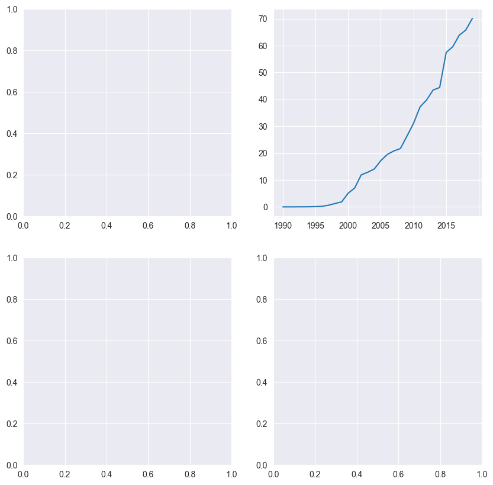

```python
# Matplotlib
import numpy as np
fig,axs = plt.subplots(2,2,figsize=(10,10))
axs[0,1].plot(mexico)
axs[0,1].set_xticks(np.arange(0,len(mexico)+1,5))
```

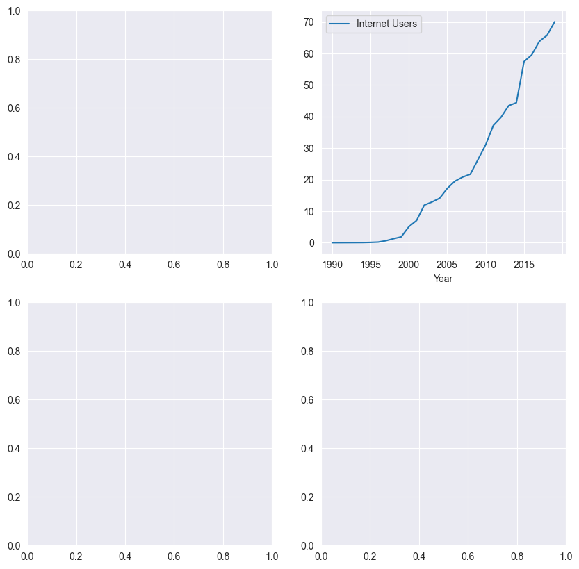

```python
# Pandas
fig,axs = plt.subplots(2,2,figsize=(10,10))
mexico.plot(ax=axs[0,1])
```

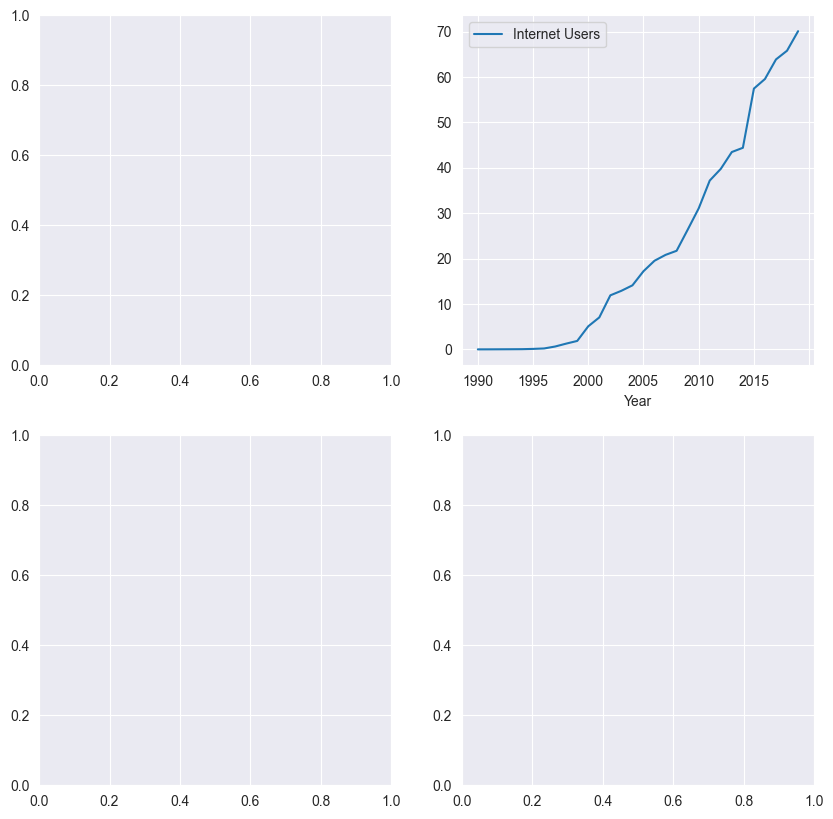

```python
# Seaborn
fig,axs = plt.subplots(2,2,figsize=(10,10))
sns.lineplot(data=mexico,ax=axs[0,1])
axs[0,1].set_xticks(np.arange(0,len(mexico)+1,5))
```

Se puede incluir el título **set_title()**, en lugar de **title()**, y las etiquetas de los ejes **set_xlabel** en vez de **xlabel**.

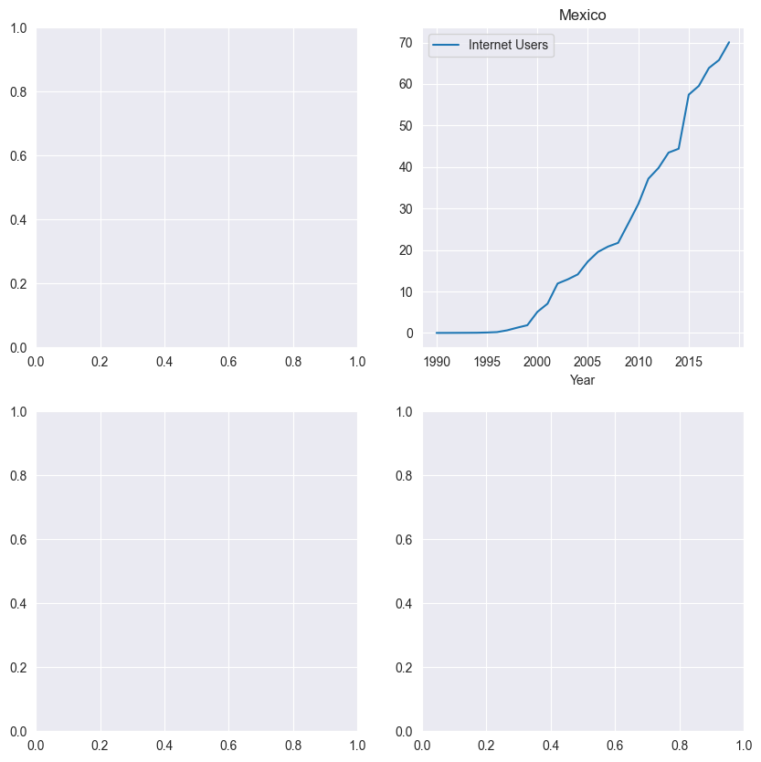

```python
fig,axs = plt.subplots(2,2,figsize=(10,10))
sns.lineplot(data=mexico,ax=axs[0,1])
axs[0,1].set_xticks(np.arange(0,len(mexico)+1,5))
axs[0,1].set_title('Mexico')
axs[0,1].set_xlabel('Year')
```

Cada subgráfica puede tener un título, pero a veces es deseable dar a la figura uno general.

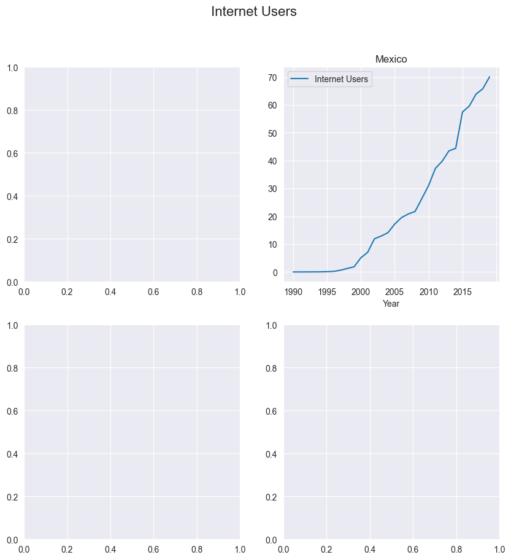

```python
fig,axs = plt.subplots(2,2,figsize=(10,10))
sns.lineplot(data=mexico,ax=axs[0,1])
axs[0,1].set_xticks(np.arange(0,len(mexico)+1,5))
fig.suptitle('Internet Users',fontsize=16)
axs[0,1].set_title('Mexico')
axs[0,1].set_xlabel('Year')
```

Para las etiquetas de los ejes de la figura se emplea **supxlabel()** y **supylabel()**.

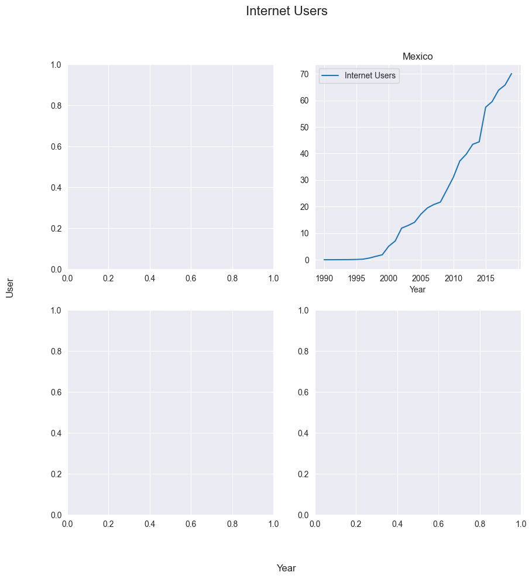

```python
fig,axs = plt.subplots(2,2,figsize=(10,10))
sns.lineplot(data=mexico,ax=axs[0,1])
axs[0,1].set_xticks(np.arange(0,len(mexico)+1,5))
fig.suptitle('Internet Users',fontsize=16)
fig.supxlabel('Year')
fig.supylabel('User')
axs[0,1].set_title('Mexico')
axs[0,1].set_xlabel('Year')
```

Hay un modo alternativo para hacer referencia a las subgráficas sin usar la posición que ocupan en la matriz. Esto es posible únicamente cuando son pocas subgráficas. Cada una de ellas se nombra durante la creación del contenedor.

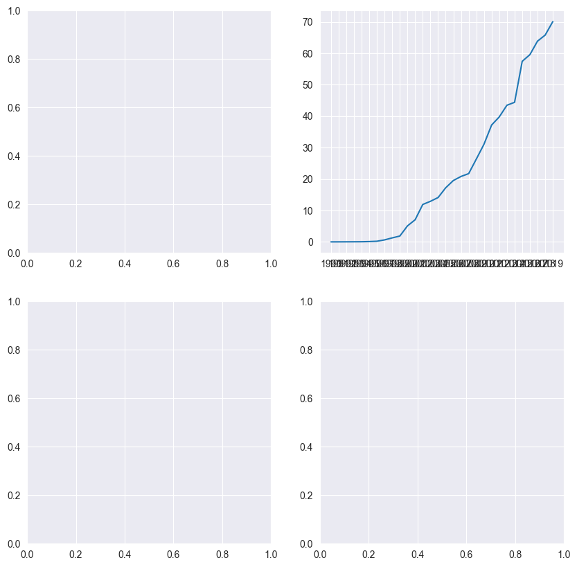

```python
fig,((ax1,ax2),(ax3,ax4)) = plt.subplots(2,2,figsize=(10,10))
ax2.plot(mexico)
```

También es posible crear la estructura de la matriz a partir de la adición de subgráficas a una figura creada.

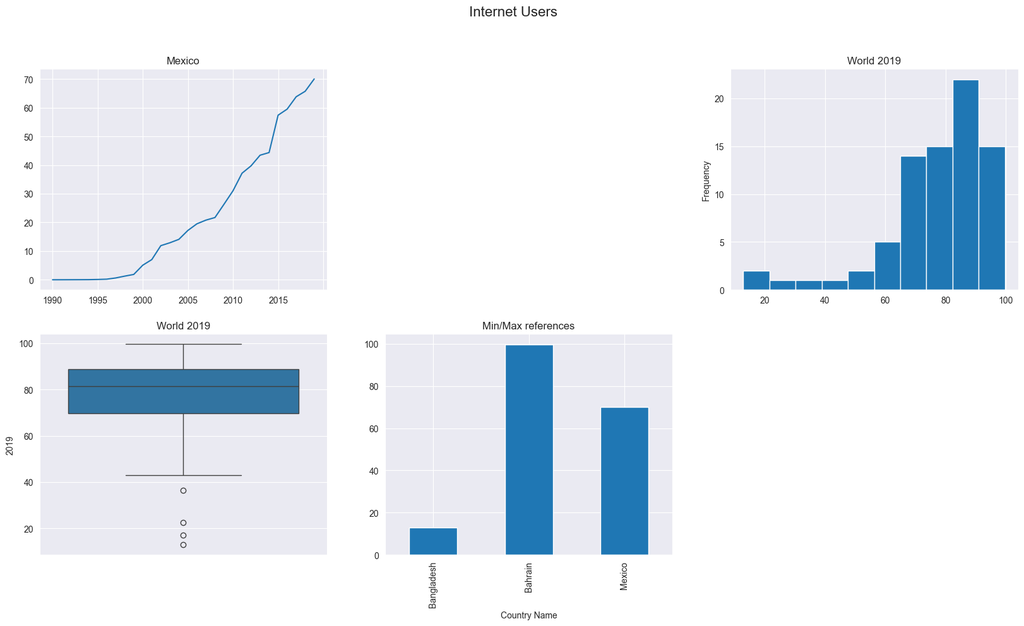

```python
fig = plt.figure(figsize=(20,10))
fig.suptitle('Internet Users',fontsize=16)

ax1 = fig.add_subplot(231)
ax1.plot(mexico)
ax1.set_xticks(np.arange(0,len(mexico)+1,5))
ax1.set_title('Mexico')

ax2 = fig.add_subplot(233)
internet_users['2019'].plot.hist(ax=ax2)
ax2.set_title('World 2019')

ax3 = fig.add_subplot(234)
sns.boxplot(y='2019',data=internet_users,orient='h',ax=ax3)
ax3.set_title('World 2019')

ax4 = fig.add_subplot(235)
ref = internet_users[(internet_users['Country Code'] == 'MEX')|
                     (internet_users['2019']==internet_users['2019'].min())|
                     (internet_users['2019']==internet_users['2019'].max())]
ref.set_index('Country Name',inplace=True)
ref = ref.drop('Country Code',axis=1)
ref['2019'].plot(kind='bar',ax=ax4)
ax4.set_title('Min/Max references')

sns.set_palette('Set2')
```

El código anterior inserta 4 subgráficas en una matriz de 2x3. En la primera línea se crea la figura, sin indicar la dimensión de la matriz. Analicemos la adición de la primera subgráfica:

`ax1 = fig.add_subplot(231)`

`ax1.plot(mexico)`

A la función **add_subplot** se le pasan tres números: los dos primeros indican la dimensión de la matriz, en este caso 2x3; y el último indica la posición de la subgráfica en dicha matriz, en este caso la 1. Las posicioens se numeran consecutivamente de izquierda a derecha.

Pandas también permite visualizar todas o algunas de las columnnas de las columnas numéricas de un dataframe como subgráficas, ocupando los parámetros **subplot** y **layout** de su función **plot()**.

### Gráficas superpuestas

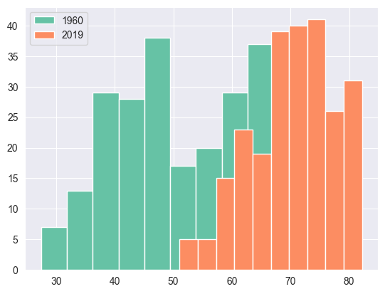

```python
# Ejemplos
lifexp_male = pd.read_csv('LifeExpectancyMale.csv')
plt.hist('1960',data=lifexp_male,label='1960')
plt.hist('2019',data=lifexp_male,label='2019')
sns.set_palette('muted')
plt.legend()
```

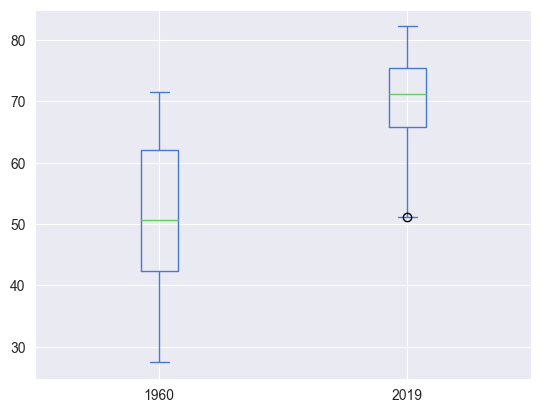

```python
lifexp_male[['1960','2019']].plot.box()
```

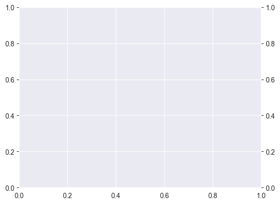

```python
# twinx()
fig, ax1 = plt.subplots()
ax2 = ax1.twinx()
```

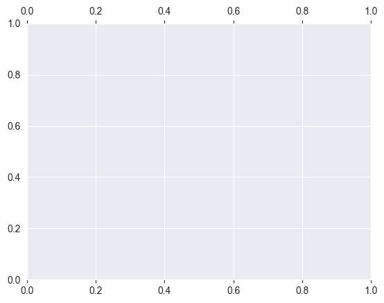

```python
# twiny()
fig,ax1 = plt.subplots()
ax2 = ax1.twiny()
```

```python
mexico_users_net = mexico
mexico_users_net.head()
```

| Year | Internet Users |
| --- | --- |
| 1990 | 0.000000 |
| 1991 | 0.005881 |
| 1992 | 0.017308 |
| 1993 | 0.028305 |
| 1994 | 0.043339 |

```python
# GNI
gni = pd.read_csv('GNI.csv')
gni_mexico = gni[gni['Country Name'] == 'Mexico']
gni_mexico.set_index('Country Name', inplace=True)
gni_mexico = gni_mexico.drop('Country Code',axis=1)
gni_mexico = gni_mexico.T
gni_mexico.index.name = 'Year'
gni_mexico.columns.name = ''
gni_mexico.columns = ['GNI']
gni_mexico = gni_mexico.loc['1990':]
gni_mexico.head()
```

| Year | GNI |
| --- | --- |
| 1990 | 2790.0 |
| 1991 | 3250.0 |
| 1992 | 3770.0 |
| 1993 | 4490.0 |
| 1994 | 5310.0 |

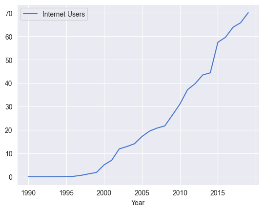

```python
mexico_users_net.plot()
```

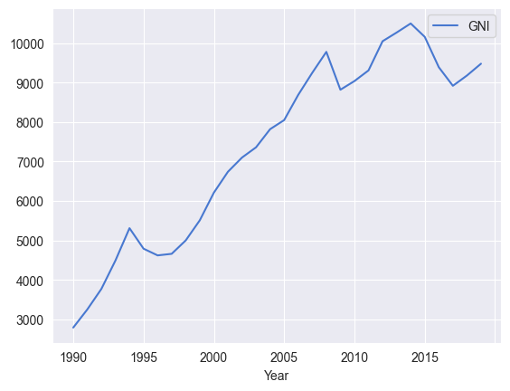

```python
gni_mexico.plot()
```

```
 [Text(0, 0, '1990'),
```

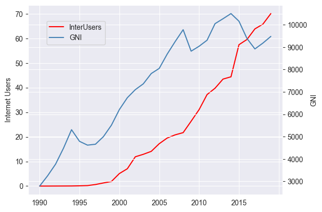

```python
# Matplotlib
mexico = pd.concat([mexico_users_net,gni_mexico],axis=1)
fig, ax1 = plt.subplots()
ax1.plot(mexico_users_net.index,mexico_users_net.values,
         label = 'InterUsers',color='red')
ax1.set_ylabel('Internet Users')

ax2 = ax1.twinx()
ax2.plot(gni_mexico.index,gni_mexico.values,label='GNI',
         color = 'steelblue')
ax2.set_ylabel('GNI')
fig.legend(bbox_to_anchor = (0.37,0.83))
plt.xticks(np.arange(0,len(mexico)+1,5))
```

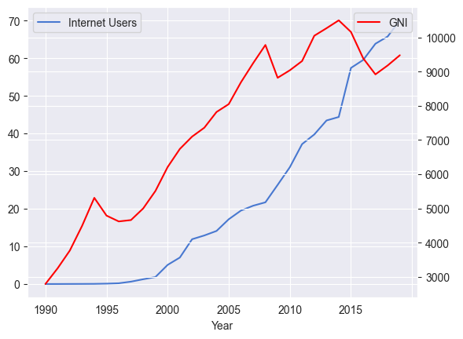

```python
# Pandas
ax1 = mexico_users_net.plot()
ax1.legend(loc='upper left')

ax2 = ax1.twinx()
gni_mexico.plot(ax=ax2,color='red')
ax2.legend(loc='upper right')
```

```
 [Text(0, 0, '1990'),
```

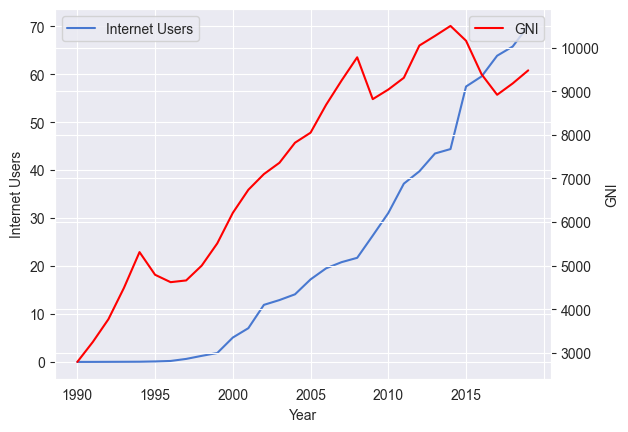

```python
# Seaborn
ax1 = sns.lineplot(data=mexico_users_net)
ax1.set_ylabel('Internet Users')
ax1.legend()

ax2 = ax1.twinx()
sns.lineplot(data=gni_mexico,ax=ax2,palette=['red'])
ax2.legend()
ax2.set_ylabel('GNI')

plt.xticks(np.arange(0,len(mexico)+1,5))
```

En los códigos anteriores se hacen creado ejes gemelos, que comparten los años en el eje x. Hay tres propuestas respecto a la asociación de las series con el eje que le corresponde según la escala.

```
 [Text(0, 0, '1990'),
```

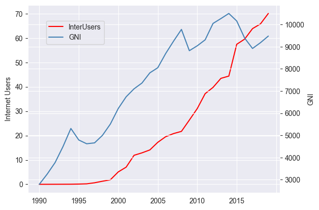

```python
# 1
mexico = pd.concat([mexico_users_net,gni_mexico],axis=1)
fig, ax1 = plt.subplots()
ax1.plot(mexico_users_net.index,mexico_users_net.values,
         label = 'InterUsers',color='red')
ax1.set_ylabel('Internet Users')

ax2 = ax1.twinx()
ax2.plot(gni_mexico.index,gni_mexico.values,label='GNI',
         color = 'steelblue')
ax2.set_ylabel('GNI')
fig.legend(bbox_to_anchor = (0.37,0.83))
plt.xticks(np.arange(0,len(mexico)+1,5))
```

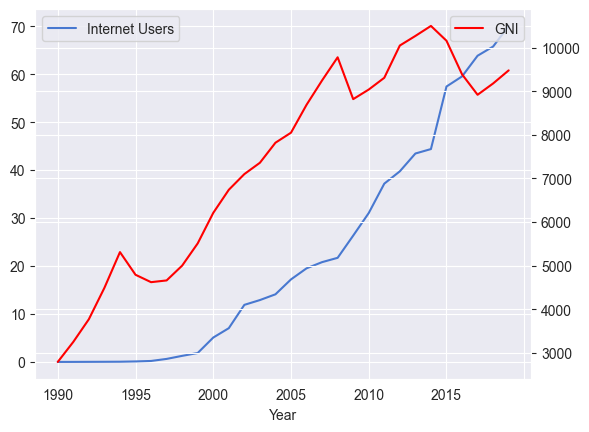

```python
# 2
ax1 = mexico_users_net.plot()
ax1.legend(loc='upper left')

ax2 = ax1.twinx()
gni_mexico.plot(ax=ax2,color='red')
ax2.legend(loc='upper right')
```

Se podría crear un gráfico con más de dos ejes duales posicionándolos mediante los **spines**, los cuales pueden colocarse en posiciones arbitrarias con la función **set_position()**.

```python
mexico_lifexp_male = lifexp_male[lifexp_male['Country Name'] == 'Mexico']
mexico_lifexp_male.set_index('Country Name',inplace = True)
mexico_lifexp_male = mexico_lifexp_male.drop('Country Code',axis=1)
mexico_lifexp_male = mexico_lifexp_male.T
mexico_lifexp_male.index.name = 'Year'
mexico_lifexp_male.columns.name = ''
mexico_lifexp_male.columns = ['Life Expectancy']
mexico_lifexp_male = mexico_lifexp_male.loc['1990':]
mexico_lifexp_male.head()
```

| Year | Life Expectancy |
| --- | --- |
| 1990 | 67.951 |
| 1991 | 68.386 |
| 1992 | 68.793 |
| 1993 | 69.171 |
| 1994 | 69.522 |

```
 [Text(0, 0, '1990'),
```

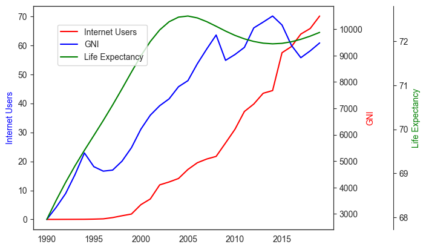

```python
sns.set_style('white')
fig,ax1 = plt.subplots()

ax1.plot(mexico_users_net.index,mexico_users_net.values,
         label='Internet Users',color='r')
ax1.set_ylabel('Internet Users',color='b')
ax1.tick_params(axis='y')

ax2 = ax1.twinx()
ax2.spines['right'].set_position(('axes',1.0))
ax2.plot(gni_mexico.index,gni_mexico.values,label='GNI',color='b')
ax2.set_ylabel('GNI',color='r')
ax2.tick_params(axis='y')

ax3 = ax1.twinx()
ax3.spines['right'].set_position(('axes',1.2))
ax3.plot(mexico_lifexp_male.index,mexico_lifexp_male.values,
         label = 'Life Expectancy',color='g')
ax3.set_ylabel('Life Expectancy',color='g')

fig.legend(bbox_to_anchor=(0.43,0.83))
plt.xticks(np.arange(0,len(mexico)+1,5))
```

Cuando se usan ejes duales, también puede combinarse varios tipos de gráficas y personalizarse como se hace cuando se ocupan subgráficas.

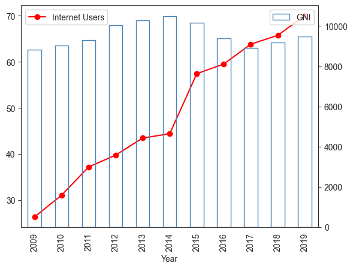

```python
ax1 = mexico_users_net['2009':'2019'].plot(rot=90,marker='o',color='r')
ax1.legend(loc='upper left')

ax2 = ax1.twinx()
gni_mexico['2009':'2019'].plot(kind='bar',ax=ax2,color='None',
                               edgecolor='steelblue')
ax2.legend(loc='upper right')
```

Se puede cambiar la escala de los ejes, como se hace con **plt.xtics()**, pero ahora usando las subgráficas.

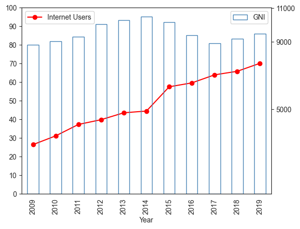

```python
ax1 = mexico_users_net.loc['2009':'2019'].plot(rot=90,marker='o',color='r')
ax1.legend(loc='upper left')
ax1.set_yticks(np.arange(0,101,10))

ax2 = ax1.twinx()
gni_mexico.loc['2009':'2019'].plot(kind='bar',ax=ax2,color='None',
                                   edgecolor='steelblue')
ax2.legend(loc='upper right')
ax2.set_yticks([5000,9000,11000])
```